# Study of household electricity consumption data

## Introduction

Electricity is an important energy in our daily life. In my project I will use the data of household electricity consumption from 2016/1/12 0:00 to 2016/1/23 23:50 to analyze the pattern and trend of people’s daily usage of electricity. The intervel of data is 10 minutes.

From these datas, I want to see the periodic pattern and trends of household electricity consumption and try to find a good model for it. For example, does people use more energy in certain time of a day or a week? Does ARMA model we learnt proper to fit the data of household electricity consumption? Is there any periodic pattern on people’s household electricity consumption?

## Data overview

We can first see the overview and plot of our data which is the data of energy consume from 2016/1/12 0:00 to 2016/1/23 23:50 and the intervel of data is 10 minutes.

```r
e <- read.csv(file="energydata_complete.csv", header = TRUE)
head(e)
```

```
##             date Appliances
## 1 2016/1/12 0:00         40
## 2 2016/1/12 0:10         30
## 3 2016/1/12 0:20         40
## 4 2016/1/12 0:30         50
## 5 2016/1/12 0:40        310
## 6 2016/1/12 0:50        380
```

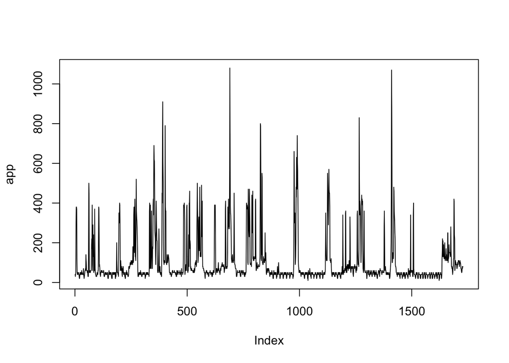

```r
app <- e$Appliances
plot(app,type = "l")
```

From the plot of data we can see a pattern of periodic and the data seems good for arma analysis.

Then we can see the acf plot of data:

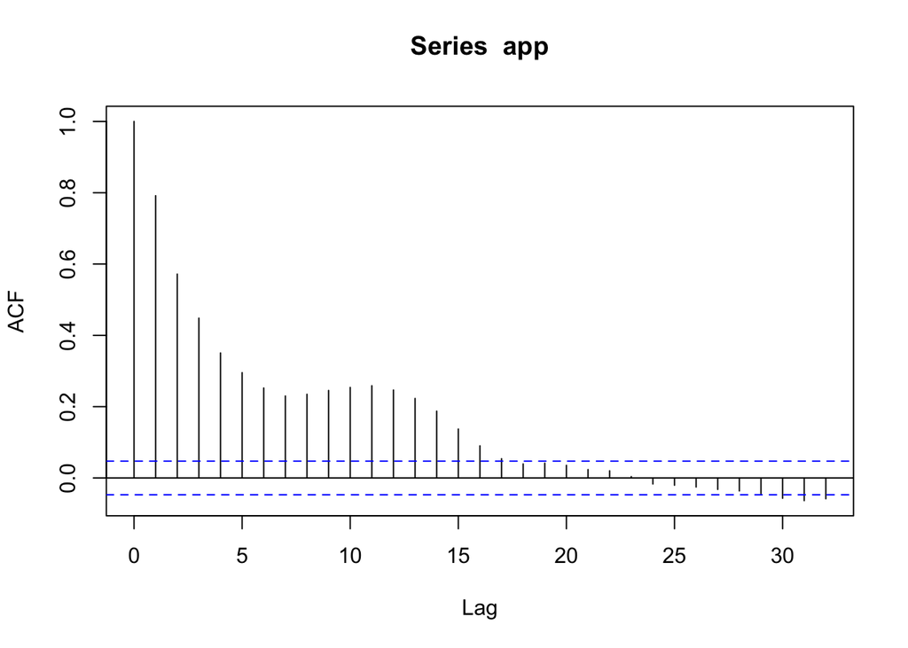

```r
acf(app, na.action = na.pass)
```

From the acf plot we can see that there is an evident for arma model since the ACF is descending and fall into confidence lag after some lag.

## Frequency domain analysis

Then we can convert the data into frequency domain and analyze the frequency property of data.

```r
spec=spectrum(app,spans=c(10,10))
```

[figure not shown]

```r
fre <- spec$freq[which.max(spec$spec)]
fre
```

```
## [1] 0.006944444
```

The domain of frequency is shown as previous 0.00694 and we can try to convert it into cycle.

Since the data we get have intervals of 10 miniutes, we can convert them into hour to see the pattern:

```r
((1/fre)*10)/60
```

```
## [1] 24
```

We can see there is a pattern of 24 hours on energy consumption which is really reasonable.

Then we can try to approach the trend of data:

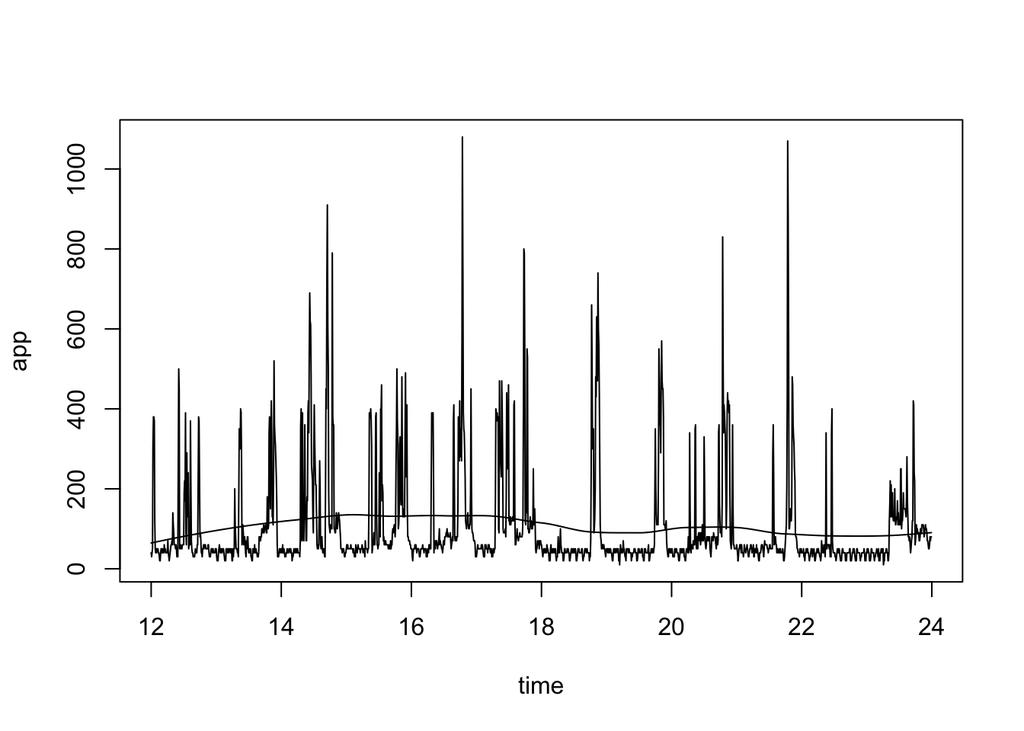

```r
time <- seq(from=12, length = length(app), by = 1/144)
plot(time, app, type = "l")
appt_l <- loess(app~time, span = 0.5)
lines(appt_l$x,appt_l$fitted,type="l")
```

[figure not shown]

```r
u_low <- ts(loess(app~time,span=0.5)$fitted,
start=12,frequency=144)
u_hi <- ts(app - loess(app~time,span=0.1)$fitted,
start=12,frequency=144)
u_cycles <- app - u_hi - u_low
plot(ts.union(app, u_low,u_hi,u_cycles),
main="Decomposition of unemployment as trend + noise + cycles")
```

## Fix with ARMA model

First I try to use ARMA(p, 0, q) to fit the data. The AIC table is shown as follow:

|  | MA0 | MA1 | MA2 | MA3 | MA4 | MA5 |
| --- | --- | --- | --- | --- | --- | --- |
| AR0 | 21651.88 | 20415.98 | 20147.03 | 19987.30 | 19947.05 | 19922.51 |
| AR1 | 19951.08 | 19899.37 | 19879.34 | 19880.95 | 19871.15 | 19871.48 |
| AR2 | 19915.11 | 19878.31 | 19879.67 | 19880.98 | 19870.54 | 19874.42 |
| AR3 | 19889.82 | 19879.79 | 19871.27 | 19872.20 | 19872.43 | 19874.50 |
| AR4 | 19888.92 | 19881.18 | 19871.72 | 19884.85 | 19874.38 | 19876.43 |
| AR5 | 19879.40 | 19873.55 | 19871.40 | 19873.92 | 19863.03 | 19865.00 |

I finally choose ARMA(2, 4) which doesn’t have the lowest AIC but have the relatively low AIC and less parameters.

So I try to use ARIMA(2, 0, 4) to fit my data:

```r
arma204 <- arima(app, order = c(2, 0, 4))
arma204
```

```
##
## Call:
## arima(x = app, order = c(2, 0, 4))
##
## Coefficients:
##          ar1      ar2      ma1      ma2     ma3      ma4  intercept
##       1.2650  -0.3167  -0.3329  -0.2873  0.0219  -0.0899   104.3127
## s.e.  0.1836   0.1643   0.1838   0.0288  0.0625   0.0322    10.9115
##
## sigma^2 estimated as 5718:  log likelihood = -9927.27,  aic = 19870.54
```

Then we can see the ma_root and ar_root of ARMA(2, 4) model.

```r
AR_roots <- polyroot(c(1,-coef(arma204)[c("ar1","ar2")]))
MA_roots <- polyroot(c(1,coef(arma204)[c("ma1","ma2","ma3","ma4")]))
```

AR roots:

```r
AR_roots
```

```
## [1] 1.085568+0i 2.908459-0i
```

MA roots:

```r
MA_roots
```

```
## [1]  1.224250+0.000000i -1.651014+0.000000i  0.335137-2.321834i
## [4]  0.335137+2.321834i
```

Since all the roots are outside the unit circle so we can prove the causality and invertibility of our model.

## Try Sarima model

Then I tray to add seasonal part in my model. In the previous section we find that there is a cycle of 24 hour for our data. Since our data has the unit of 10 minites. So we add a period of 144. The information of new SARIMA model:

```r
arma204101 <- arima(app,
                    order = c(2,0,4),                           seasonal=list(order=c(0,1,0),period=144))
```

```r
arma204101
```

```
##
## Call:
## arima(x = app, order = c(2, 0, 4), seasonal = list(order = c(0, 1, 0), period = 144))
##
## Coefficients:
##           ar1     ar2     ma1     ma2      ma3      ma4
##       -0.0833  0.5370  0.9471  0.0376  -0.0345  -0.0003
## s.e.   0.1603  0.0954  0.1616  0.1031   0.0707   0.0432
##
## sigma^2 estimated as 10799:  log likelihood = -9603.52,  aic = 19221.04
```

We can see there is a decreasing of aic which may indicate that SARIMA model fits the data better than ARIMA model.

I finally use $SARIMA(2, 0, 4) * (0, 1, 0)_144$ as model to fit the data of energy consumption.

## Diagnostic Analysis

We can first see the plot of residual of the fitted model. The plot and acf plot of residual can be shown as follow:

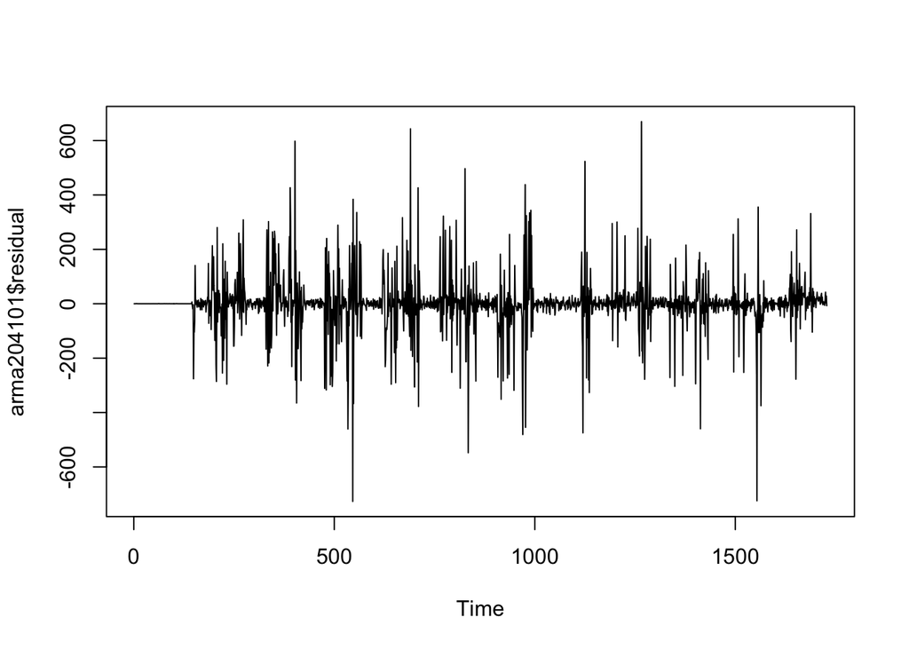

```r
plot(arma204101$residual)
```

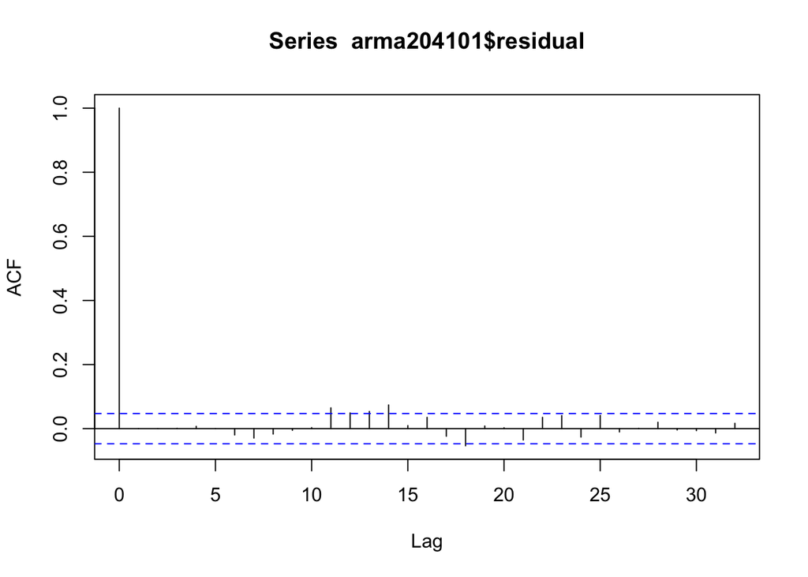

```r
acf(arma204101$residual)
```

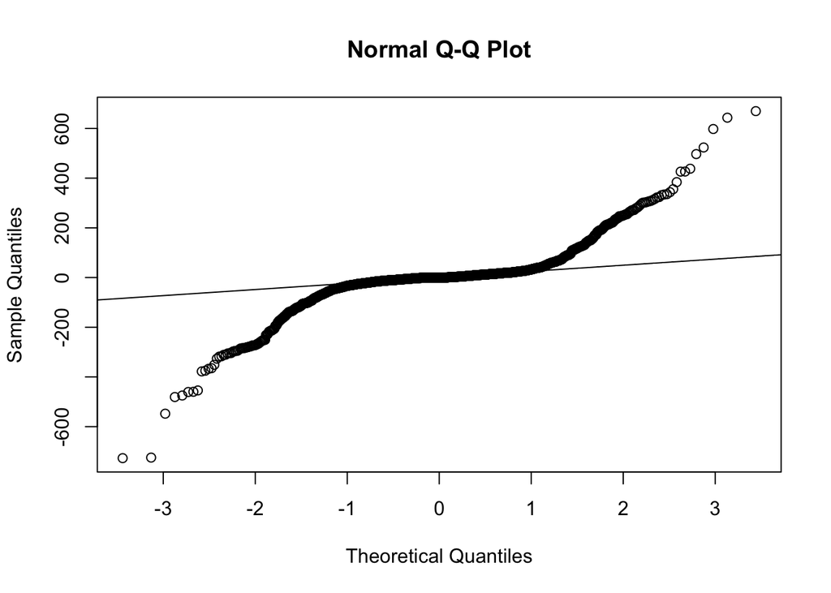

```r
qqnorm(arma204101$residual)
qqline(arma204101$residual)
```

From the qqplot we can see that it has a tail near the end and the tail can’t be neglected. So we can conclude that the model is good for the data but we can still improve the model by adding more parameters or we can try to seek for better performance by looking for some enhanced models.

## Reference

[1]Dataset https://archive.ics.uci.edu/ml/machine-learning-databases/00374/

[2]STATS 531 course notations: Some R codes are modified from course notations.